# environmental_data_preperation

# AMO data

Downloaded from [NOAA](https://www.esrl.noaa.gov/psd/data/timeseries/AMO/) (AMO, unsmoothed, short) as a txt and then converted to a .csv

load raw data

```r
amoraw <- read.csv("../data/env/amon.us.data.csv", header = FALSE)
head(amoraw)
```

|  | V1 | V2 | V3 | V4 | V5 | V6 | V7 | V8 | V9 | V10 | V11 | V12 | V13 |
| --- | --- | --- | --- | --- | --- | --- | --- | --- | --- | --- | --- | --- | --- |
| 1 | 1948 | -0.014 | -0.026 | 0.030 | -0.068 | -0.002 | 0.057 | -0.038 | -0.021 | -0.051 | 0.009 | 0.136 | 0.064 |
| 2 | 1949 | 0.155 | 0.162 | 0.040 | 0.101 | -0.022 | 0.003 | 0.073 | 0.104 | 0.072 | 0.106 | 0.110 | 0.120 |
| 3 | 1950 | 0.113 | -0.032 | -0.104 | -0.128 | -0.056 | -0.041 | -0.053 | 0.022 | 0.012 | -0.088 | 0.082 | 0.090 |
| 4 | 1951 | 0.105 | 0.000 | 0.014 | 0.171 | 0.174 | 0.291 | 0.424 | 0.305 | 0.251 | 0.261 | 0.177 | 0.177 |
| 5 | 1952 | 0.174 | 0.184 | 0.232 | 0.193 | 0.183 | 0.385 | 0.374 | 0.405 | 0.364 | 0.356 | 0.252 | 0.342 |
| 6 | 1953 | 0.267 | 0.187 | 0.143 | 0.315 | 0.344 | 0.277 | 0.345 | 0.260 | 0.282 | 0.150 | 0.246 | 0.260 |

ok first col = year, the others represent the month. Give the columns some proper names

```r
colnames(amoraw) <- c("year","Jan", "Feb", "Mar", "Apr", "May", "Jun", "Jul", "Aug", "Sep", "Oct", "Nov", "Dec")
head(amoraw)
```

|  | year | Jan | Feb | Mar | Apr | May | Jun | Jul | Aug | Sep | Oct | Nov | Dec |
| --- | --- | --- | --- | --- | --- | --- | --- | --- | --- | --- | --- | --- | --- |
| 1 | 1948 | -0.014 | -0.026 | 0.030 | -0.068 | -0.002 | 0.057 | -0.038 | -0.021 | -0.051 | 0.009 | 0.136 | 0.064 |
| 2 | 1949 | 0.155 | 0.162 | 0.040 | 0.101 | -0.022 | 0.003 | 0.073 | 0.104 | 0.072 | 0.106 | 0.110 | 0.120 |
| 3 | 1950 | 0.113 | -0.032 | -0.104 | -0.128 | -0.056 | -0.041 | -0.053 | 0.022 | 0.012 | -0.088 | 0.082 | 0.090 |
| 4 | 1951 | 0.105 | 0.000 | 0.014 | 0.171 | 0.174 | 0.291 | 0.424 | 0.305 | 0.251 | 0.261 | 0.177 | 0.177 |
| 5 | 1952 | 0.174 | 0.184 | 0.232 | 0.193 | 0.183 | 0.385 | 0.374 | 0.405 | 0.364 | 0.356 | 0.252 | 0.342 |
| 6 | 1953 | 0.267 | 0.187 | 0.143 | 0.315 | 0.344 | 0.277 | 0.345 | 0.260 | 0.282 | 0.150 | 0.246 | 0.260 |

The data downloaded from the site indidcated that NA values are represented by -99.99. Lets replace those values with NA

```r
amoraw <- replace(amoraw,amoraw==-99.99, NA)
```

Now subset the dataset to start in 1996 (the capelin data starts in 1998, but you want some previous time period stuff)

```r
amoraw <- amoraw[amoraw$year >= 1996, ]
head(amoraw)
```

|  | year | Jan | Feb | Mar | Apr | May | Jun | Jul | Aug | Sep | Oct | Nov | Dec |
| --- | --- | --- | --- | --- | --- | --- | --- | --- | --- | --- | --- | --- | --- |
| 49 | 1996 | -0.010 | -0.032 | -0.058 | 0.009 | -0.065 | -0.124 | -0.105 | -0.008 | -0.002 | -0.145 | -0.174 | -0.155 |
| 50 | 1997 | -0.091 | -0.036 | 0.005 | 0.007 | 0.040 | 0.008 | 0.060 | 0.015 | 0.109 | 0.150 | 0.051 | 0.131 |
| 51 | 1998 | 0.130 | 0.291 | 0.322 | 0.291 | 0.383 | 0.489 | 0.487 | 0.512 | 0.412 | 0.382 | 0.317 | 0.279 |
| 52 | 1999 | 0.051 | 0.057 | 0.069 | 0.052 | 0.162 | 0.180 | 0.198 | 0.307 | 0.185 | 0.017 | -0.049 | 0.014 |
| 53 | 2000 | -0.084 | -0.038 | 0.103 | 0.042 | 0.105 | -0.018 | 0.072 | 0.103 | 0.101 | -0.040 | -0.053 | -0.127 |
| 54 | 2001 | -0.128 | -0.027 | 0.014 | -0.012 | -0.009 | 0.198 | 0.135 | 0.177 | 0.286 | 0.251 | 0.156 | 0.213 |

And just for fun, plot the AMO… follow the tutorial [here](http://www.stat.pitt.edu/stoffer/tsa4/R_toot.htm)

```r
amocolumn <- matrix(t(amoraw[ ,2:13]), ncol=1) #month data is in col 2 - 13
amocolumn1 <- as.vector(amocolumn)
amotimeseries <- ts(amocolumn1, frequency = 12, start = c(1996,1))
plot.ts(amotimeseries)
abline(h = 0)
```

```r
dev.copy(png, "../output/env/amo.png") #this prints a png of the plot
```

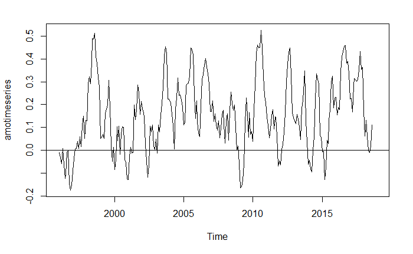

```r
dev.off() #this turns off the print command
```

First I will create a matrix that takes all of the raw data and then appends some extra columns - year average value, year phase (warm or cold) and then seasonal values (spring, summer, autum, winter) + seasonal phase (warm cold)

Spring: 1 March - 31 May (col 4:6) Summer: 1 June - 31 August (col 7:9) Autumn: 1 Sept - 31 Nov (col 10:12) Winter: 1 Dec - 28 Feb (col 13 from prev year, 1:2)

```r
amophases <- amoraw
amophases$YearAvg <- rowMeans(amophases[2:13], na.rm = TRUE) #the month data is in col 2-13
amophases$SpringAvg <-  rowMeans(amophases[4:6], na.rm = TRUE)
amophases$SummerAvg <-  rowMeans(amophases[7:9], na.rm = TRUE)
amophases$AutumnAvg <-  rowMeans(amophases[10:12], na.rm = TRUE)
```

winter has a different format - the columns are in 1 & 2, & 13 from the previous column, which means the rowmeans function needs a bit of tweaking…

1. shift the dec column you created down by 1

```r
library(useful)
amophases <- shift.column(data = amophases, columns = "Dec", len = 1, up = FALSE)
amophases
```

|  | year | Jan | Feb | Mar | Apr | May | Jun | Jul | Aug | Sep | Oct | Nov | Dec | YearAvg | SpringAvg | SummerAvg | AutumnAvg | Dec.Shifted |
| --- | --- | --- | --- | --- | --- | --- | --- | --- | --- | --- | --- | --- | --- | --- | --- | --- | --- | --- |
| 50 | 1997 | -0.091 | -0.036 | 0.005 | 0.007 | 0.040 | 0.008 | 0.060 | 0.015 | 0.109 | 0.150 | 0.051 | 0.131 | 0.03741667 | 0.017333333 | 0.02766667 | 0.103333333 | -0.155 |
| 51 | 1998 | 0.130 | 0.291 | 0.322 | 0.291 | 0.383 | 0.489 | 0.487 | 0.512 | 0.412 | 0.382 | 0.317 | 0.279 | 0.35791667 | 0.332000000 | 0.49600000 | 0.370333333 | 0.131 |
| 52 | 1999 | 0.051 | 0.057 | 0.069 | 0.052 | 0.162 | 0.180 | 0.198 | 0.307 | 0.185 | 0.017 | -0.049 | 0.014 | 0.10358333 | 0.094333333 | 0.22833333 | 0.051000000 | 0.279 |
| 53 | 2000 | -0.084 | -0.038 | 0.103 | 0.042 | 0.105 | -0.018 | 0.072 | 0.103 | 0.101 | -0.040 | -0.053 | -0.127 | 0.01383333 | 0.083333333 | 0.05233333 | 0.002666667 | 0.014 |
| 54 | 2001 | -0.128 | -0.027 | 0.014 | -0.012 | -0.009 | 0.198 | 0.135 | 0.177 | 0.286 | 0.251 | 0.156 | 0.213 | 0.10450000 | -0.002333333 | 0.17000000 | 0.231000000 | -0.127 |
| 55 | 2002 | 0.181 | 0.165 | 0.145 | 0.027 | -0.048 | -0.117 | -0.066 | 0.106 | 0.080 | 0.111 | 0.019 | 0.004 | 0.05058333 | 0.041333333 | -0.02566667 | 0.070000000 | 0.213 |
| 56 | 2003 | 0.050 | -0.013 | 0.112 | 0.079 | 0.151 | 0.205 | 0.276 | 0.415 | 0.452 | 0.426 | 0.223 | 0.224 | 0.21666667 | 0.114000000 | 0.29866667 | 0.367000000 | 0.004 |
| 57 | 2004 | 0.210 | 0.209 | 0.158 | 0.108 | 0.006 | 0.177 | 0.228 | 0.317 | 0.240 | 0.242 | 0.221 | 0.187 | 0.19191667 | 0.090666667 | 0.24066667 | 0.234333333 | 0.224 |
| 58 | 2005 | 0.111 | 0.125 | 0.284 | 0.292 | 0.293 | 0.327 | 0.447 | 0.440 | 0.419 | 0.238 | 0.140 | 0.216 | 0.27766667 | 0.289666667 | 0.40466667 | 0.265666667 | 0.187 |
| 59 | 2006 | 0.123 | 0.075 | 0.060 | 0.197 | 0.308 | 0.333 | 0.374 | 0.401 | 0.364 | 0.334 | 0.289 | 0.171 | 0.25241667 | 0.188333333 | 0.36933333 | 0.329000000 | 0.216 |

[output cut: 12 more lines]

```r
write.csv(amophases, file = "../output/env/amo.csv", row.names = FALSE) #for some reason you need to write to a csv and then reload for the next step to work properly...
```

the shifted data is in Dec.Shifted…

```r
amophases <- read.csv("../output/env/amo.csv")
amophases$WinterAvg <- rowMeans(amophases[, c("Dec.Shifted", "Jan", "Feb")], na.rm = TRUE)
amophases
```

| year | Jan | Feb | Mar | Apr | May | Jun | Jul | Aug | Sep | Oct | Nov | Dec | YearAvg | SpringAvg | SummerAvg | AutumnAvg | Dec.Shifted | WinterAvg |
| --- | --- | --- | --- | --- | --- | --- | --- | --- | --- | --- | --- | --- | --- | --- | --- | --- | --- | --- |
| 1997 | -0.091 | -0.036 | 0.005 | 0.007 | 0.040 | 0.008 | 0.060 | 0.015 | 0.109 | 0.150 | 0.051 | 0.131 | 0.03741667 | 0.017333333 | 0.02766667 | 0.103333333 | -0.155 | -0.09400000 |
| 1998 | 0.130 | 0.291 | 0.322 | 0.291 | 0.383 | 0.489 | 0.487 | 0.512 | 0.412 | 0.382 | 0.317 | 0.279 | 0.35791667 | 0.332000000 | 0.49600000 | 0.370333333 | 0.131 | 0.18400000 |
| 1999 | 0.051 | 0.057 | 0.069 | 0.052 | 0.162 | 0.180 | 0.198 | 0.307 | 0.185 | 0.017 | -0.049 | 0.014 | 0.10358333 | 0.094333333 | 0.22833333 | 0.051000000 | 0.279 | 0.12900000 |
| 2000 | -0.084 | -0.038 | 0.103 | 0.042 | 0.105 | -0.018 | 0.072 | 0.103 | 0.101 | -0.040 | -0.053 | -0.127 | 0.01383333 | 0.083333333 | 0.05233333 | 0.002666667 | 0.014 | -0.03600000 |
| 2001 | -0.128 | -0.027 | 0.014 | -0.012 | -0.009 | 0.198 | 0.135 | 0.177 | 0.286 | 0.251 | 0.156 | 0.213 | 0.10450000 | -0.002333333 | 0.17000000 | 0.231000000 | -0.127 | -0.09400000 |
| 2002 | 0.181 | 0.165 | 0.145 | 0.027 | -0.048 | -0.117 | -0.066 | 0.106 | 0.080 | 0.111 | 0.019 | 0.004 | 0.05058333 | 0.041333333 | -0.02566667 | 0.070000000 | 0.213 | 0.18633333 |
| 2003 | 0.050 | -0.013 | 0.112 | 0.079 | 0.151 | 0.205 | 0.276 | 0.415 | 0.452 | 0.426 | 0.223 | 0.224 | 0.21666667 | 0.114000000 | 0.29866667 | 0.367000000 | 0.004 | 0.01366667 |
| 2004 | 0.210 | 0.209 | 0.158 | 0.108 | 0.006 | 0.177 | 0.228 | 0.317 | 0.240 | 0.242 | 0.221 | 0.187 | 0.19191667 | 0.090666667 | 0.24066667 | 0.234333333 | 0.224 | 0.21433333 |
| 2005 | 0.111 | 0.125 | 0.284 | 0.292 | 0.293 | 0.327 | 0.447 | 0.440 | 0.419 | 0.238 | 0.140 | 0.216 | 0.27766667 | 0.289666667 | 0.40466667 | 0.265666667 | 0.187 | 0.14100000 |
| 2006 | 0.123 | 0.075 | 0.060 | 0.197 | 0.308 | 0.333 | 0.374 | 0.401 | 0.364 | 0.334 | 0.289 | 0.171 | 0.25241667 | 0.188333333 | 0.36933333 | 0.329000000 | 0.216 | 0.13800000 |

[output cut: 12 more lines]

Now label the phases positive, negative (or avg if any happen to be at 0)

```r
amophases$YearPhase[amophases$YearAvg ==0] <- "avg"
amophases$YearPhase[amophases$YearAvg >0] <- "positive"
amophases$YearPhase[amophases$YearAvg <0] <- "negative"
amophases$SpringPhase[amophases$SpringAvg ==0] <- "avg"
amophases$SpringPhase[amophases$SpringAvg >0] <- "positive"
amophases$SpringPhase[amophases$SpringAvg <0] <- "negative"
amophases$SummerPhase[amophases$SummerAvg ==0] <- "avg"
amophases$SummerPhase[amophases$SummerAvg >0] <- "positive"
amophases$SummerPhase[amophases$SummerAvg <0] <- "negative"
amophases$AutumnPhase[amophases$AutumnAvg ==0] <- "avg"
amophases$AutumnPhase[amophases$AutumnAvg >0] <- "positive"
amophases$AutumnPhase[amophases$AutumnAvg <0] <- "negative"
amophases$WinterPhase[amophases$WinterAvg ==0] <- "avg"
amophases$WinterPhase[amophases$WinterAvg >0] <- "positive"
amophases$WinterPhase[amophases$WinterAvg <0] <- "negative"
```

now save this as a new csv

```r
write.csv(amophases, file = "../output/env/amo.csv", row.names = FALSE)
```

# NAO

Dataset mes from [NCAR](https://climatedataguide.ucar.edu/climate-data/hurrell-north-atlantic-oscillation-nao-index-pc-based). Note I am using the monthly principal component (PC)-based indices of the North Atlantic Oscillation [(NAO)](https://climatedataguide.ucar.edu/sites/default/files/nao_pc_monthly.txt). I have already converted this file into a csv and removed unncesessary text. Note there are no headers…

```r
naoraw <- read.csv("../data/env/nao_pc_monthly.csv", header = FALSE)
head(naoraw)
```

|  | V1 | V2 | V3 | V4 | V5 | V6 | V7 | V8 | V9 | V10 | V11 | V12 | V13 |
| --- | --- | --- | --- | --- | --- | --- | --- | --- | --- | --- | --- | --- | --- |
| 1 | 1899 | -0.07 | -0.71 | -1.05 | -0.43 | -0.61 | 0.15 | 0.21 | -0.60 | 0.49 | 0.20 | 0.61 | -1.09 |
| 2 | 1900 | 0.34 | -2.56 | -1.34 | 0.53 | 0.03 | -0.25 | -0.40 | -0.20 | 0.72 | 0.16 | 0.12 | 0.77 |
| 3 | 1901 | 0.26 | -2.07 | -0.42 | 0.29 | -0.49 | 0.42 | -0.05 | 0.14 | -0.07 | 0.34 | -0.94 | -0.43 |
| 4 | 1902 | 0.25 | -2.39 | -0.17 | -0.83 | 0.06 | -1.32 | -0.60 | -0.65 | -0.55 | 0.22 | -0.22 | 0.38 |
| 5 | 1903 | 0.22 | 2.22 | 2.23 | -0.54 | 0.24 | -1.31 | -0.50 | -0.09 | -0.28 | -0.57 | 0.64 | -0.20 |
| 6 | 1904 | 0.88 | 0.09 | 0.13 | 1.64 | 0.48 | -0.10 | -0.22 | -0.34 | -0.06 | 0.44 | -0.27 | -0.18 |

lets give some column names. col 1 year, 2:13 are the months

```r
colnames(naoraw) <- c("year","1", "2", "3", "4", "5", "6", "7", "8", "9", "10", "11", "12")
head(naoraw)
```

|  | year | 1 | 2 | 3 | 4 | 5 | 6 | 7 | 8 | 9 | 10 | 11 | 12 |
| --- | --- | --- | --- | --- | --- | --- | --- | --- | --- | --- | --- | --- | --- |
| 1 | 1899 | -0.07 | -0.71 | -1.05 | -0.43 | -0.61 | 0.15 | 0.21 | -0.60 | 0.49 | 0.20 | 0.61 | -1.09 |
| 2 | 1900 | 0.34 | -2.56 | -1.34 | 0.53 | 0.03 | -0.25 | -0.40 | -0.20 | 0.72 | 0.16 | 0.12 | 0.77 |
| 3 | 1901 | 0.26 | -2.07 | -0.42 | 0.29 | -0.49 | 0.42 | -0.05 | 0.14 | -0.07 | 0.34 | -0.94 | -0.43 |
| 4 | 1902 | 0.25 | -2.39 | -0.17 | -0.83 | 0.06 | -1.32 | -0.60 | -0.65 | -0.55 | 0.22 | -0.22 | 0.38 |
| 5 | 1903 | 0.22 | 2.22 | 2.23 | -0.54 | 0.24 | -1.31 | -0.50 | -0.09 | -0.28 | -0.57 | 0.64 | -0.20 |
| 6 | 1904 | 0.88 | 0.09 | 0.13 | 1.64 | 0.48 | -0.10 | -0.22 | -0.34 | -0.06 | 0.44 | -0.27 | -0.18 |

NA values are represented by -999. Change these to NA

```r
naoraw <- replace(naoraw,naoraw==-999, NA)
```

Now subset the dataset to start in 1996 (the capelin data starts in 1998, but you want some previous time period stuff)

```r
nao <- naoraw[naoraw$year >= 1996, ]
head(nao)
```

|  | year | 1 | 2 | 3 | 4 | 5 | 6 | 7 | 8 | 9 | 10 | 11 | 12 |
| --- | --- | --- | --- | --- | --- | --- | --- | --- | --- | --- | --- | --- | --- |
| 98 | 1996 | -1.33 | -0.02 | -1.16 | -0.94 | -0.52 | 0.50 | 0.73 | 0.09 | -0.90 | 0.10 | 0.37 | -2.15 |
| 99 | 1997 | -0.56 | 3.07 | 2.04 | -0.33 | -0.51 | -1.04 | -0.13 | 0.31 | 0.21 | -1.23 | -1.13 | -0.51 |
| 100 | 1998 | -1.01 | 0.54 | 0.58 | -0.45 | 0.29 | -0.94 | 0.02 | 0.63 | -1.89 | 0.41 | -0.49 | 1.48 |
| 101 | 1999 | 0.69 | 1.06 | -0.87 | -0.35 | 0.41 | 1.03 | 0.02 | -0.42 | -0.22 | -0.08 | 0.96 | 1.00 |
| 102 | 2000 | 1.11 | 2.86 | 0.30 | -0.63 | 0.79 | 0.25 | -0.58 | 0.32 | 0.46 | 0.92 | -1.08 | -1.49 |
| 103 | 2001 | -0.28 | -0.31 | -1.93 | 0.48 | 0.13 | -0.31 | -0.15 | 0.57 | -0.84 | 0.59 | 1.21 | -1.55 |

```r
summary(nao)
```

```
      year            1                 2                 3                  4                  5                 6                 7
 Min.   :1996   Min.   :-2.1100   Min.   :-3.9800   Min.   :-4.11000   Min.   :-1.29000   Min.   :-1.3300   Min.   :-1.2500   Min.   :-1.24000
 1st Qu.:2002   1st Qu.:-0.4650   1st Qu.:-0.5750   1st Qu.:-1.01500   1st Qu.:-0.49500   1st Qu.:-0.4150   1st Qu.:-0.8250   1st Qu.:-0.31000
 Median :2007   Median : 0.1700   Median : 0.5800   Median : 0.58000   Median :-0.02000   Median : 0.1300   Median :-0.2300   Median :-0.12000
 Mean   :2007   Mean   : 0.1361   Mean   : 0.3704   Mean   : 0.05261   Mean   : 0.02087   Mean   : 0.1487   Mean   :-0.1922   Mean   :-0.07609
 3rd Qu.:2012   3rd Qu.: 0.8000   3rd Qu.: 1.2350   3rd Qu.: 1.07500   3rd Qu.: 0.43000   3rd Qu.: 0.6050   3rd Qu.: 0.3250   3rd Qu.: 0.23000
 Max.   :2018   Max.   : 2.0100   Max.   : 3.0700   Max.   : 2.36000   Max.   : 2.31000   Max.   : 1.7100   Max.   : 1.0300   Max.   : 0.73000

       8                  9                  10                11                12
 Min.   :-0.97000   Min.   :-1.89000   Min.   :-1.8900   Min.   :-1.6400   Min.   :-3.630
 1st Qu.:-0.42750   1st Qu.:-0.46500   1st Qu.:-1.0275   1st Qu.:-0.3600   1st Qu.:-1.455
 Median :-0.06500   Median : 0.07500   Median :-0.5500   Median : 0.1100   Median : 0.480
 Mean   :-0.07864   Mean   :-0.07136   Mean   :-0.3745   Mean   : 0.1150   Mean   : 0.075
 3rd Qu.: 0.27750   3rd Qu.: 0.41750   3rd Qu.: 0.3975   3rd Qu.: 0.6925   3rd Qu.: 1.465
 Max.   : 0.79000   Max.   : 1.00000   Max.   : 1.2000   Max.   : 1.5700   Max.   : 2.600
 NA's   :1          NA's   :1          NA's   :1         NA's   :1         NA's   :1
```

And just for fun, plot the NAO follow the tutorial here

```r
naocolumn <- matrix(t(nao[ ,2:13]), ncol=1) #month data is in col 2 - 13 xxxxerror corrected
naocolumn1 <- as.vector(naocolumn)
naotimeseries <- ts(naocolumn1, frequency = 12, start = c(1996,1))
plot.ts(naotimeseries)
abline(h = 0)
```

```r
dev.copy(png, "../output/env/nao.png") #this prints a png of the plot
```

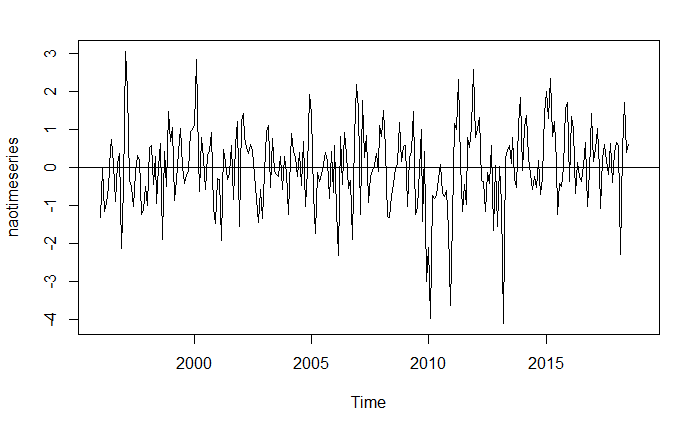

```r
dev.off() #this turns off the print command
```

First I will create a matrix that takes all of the raw data and then appends some extra columns - year average value, year phase (warm or cold) and then seasonal values (spring, summer, autum, winter) + seasonal phase (warm cold)

Spring: 1 March - 31 May (col 4:6) Summer: 1 June - 31 August (col 7:9) Autumn: 1 Sept - 31 Nov (col 10:12) Winter: 1 Dec - 28 Feb (col 13 from prev year, 1:2)

```r
naophases <- nao
naophases$YearAvg <- rowMeans(naophases[2:13], na.rm = TRUE) #the month data is in col 2-13
naophases$SpringAvg <- rowMeans(naophases[4:6], na.rm = TRUE)
naophases$SummerAvg <- rowMeans(naophases[7:9], na.rm = TRUE)
naophases$AutumnAvg <- rowMeans(naophases[10:12], na.rm = TRUE)
```

winter has a different format - the columns are in 1 & 2, & 13 from the previous column, which means the rowmeans function needs a bit of tweaking…

shift the dec column you created down by 1

```r
library(useful)
naophases <- shift.column(data = naophases, columns = "12", len = 1, up = FALSE)
naophases
```

|  | year | 1 | 2 | 3 | 4 | 5 | 6 | 7 | 8 | 9 | 10 | 11 | 12 | YearAvg | SpringAvg | SummerAvg | AutumnAvg | 12.Shifted |
| --- | --- | --- | --- | --- | --- | --- | --- | --- | --- | --- | --- | --- | --- | --- | --- | --- | --- | --- |
| 99 | 1997 | -0.56 | 3.07 | 2.04 | -0.33 | -0.51 | -1.04 | -0.13 | 0.31 | 0.21 | -1.23 | -1.13 | -0.51 | 0.01583333 | 0.40000000 | -2.866667e-01 | -7.166667e-01 | -2.15 |
| 100 | 1998 | -1.01 | 0.54 | 0.58 | -0.45 | 0.29 | -0.94 | 0.02 | 0.63 | -1.89 | 0.41 | -0.49 | 1.48 | -0.06916667 | 0.14000000 | -9.666667e-02 | -6.566667e-01 | -0.51 |
| 101 | 1999 | 0.69 | 1.06 | -0.87 | -0.35 | 0.41 | 1.03 | 0.02 | -0.42 | -0.22 | -0.08 | 0.96 | 1.00 | 0.26916667 | -0.27000000 | 2.100000e-01 | 2.200000e-01 | 1.48 |
| 102 | 2000 | 1.11 | 2.86 | 0.30 | -0.63 | 0.79 | 0.25 | -0.58 | 0.32 | 0.46 | 0.92 | -1.08 | -1.49 | 0.26916667 | 0.15333333 | -3.333333e-03 | 1.000000e-01 | 1.00 |
| 103 | 2001 | -0.28 | -0.31 | -1.93 | 0.48 | 0.13 | -0.31 | -0.15 | 0.57 | -0.84 | 0.59 | 1.21 | -1.55 | -0.19916667 | -0.44000000 | 3.666667e-02 | 3.200000e-01 | -1.49 |
| 104 | 2002 | 1.22 | 1.43 | 0.80 | 0.52 | 0.36 | 0.61 | 0.46 | -0.21 | -0.83 | -1.45 | -0.58 | -1.35 | 0.08166667 | 0.56000000 | 2.866667e-01 | -9.533333e-01 | -1.55 |
| 105 | 2003 | -0.13 | 0.95 | 1.11 | -0.54 | 0.76 | -0.08 | -0.19 | -0.23 | 0.29 | -0.58 | 0.28 | -0.14 | 0.12500000 | 0.44333333 | -1.666667e-01 | -3.333333e-03 | -1.35 |
| 106 | 2004 | -1.23 | -0.45 | 0.89 | 0.41 | 0.27 | -0.23 | 0.40 | -0.47 | 0.69 | -1.02 | -0.08 | 1.93 | 0.09250000 | 0.52333333 | -1.000000e-01 | -1.366667e-01 | -0.14 |
| 107 | 2005 | 1.43 | -0.70 | -1.75 | -0.13 | -0.38 | -0.19 | 0.07 | 0.39 | 0.15 | -0.81 | 0.43 | -0.66 | -0.17916667 | -0.75333333 | 9.000000e-02 | -7.666667e-02 | 1.93 |
| 108 | 2006 | 0.58 | -1.14 | -2.32 | 0.82 | -0.45 | 0.92 | 0.35 | -0.56 | -0.33 | -1.89 | 0.78 | 2.19 | -0.08750000 | -0.65000000 | 2.366667e-01 | -4.800000e-01 | -0.66 |

[output cut: 12 more lines]

```r
write.csv(naophases, file = "../output/env/nao.csv", row.names = FALSE) #for some reason you need to write to a csv and then reload for the next step to work properly...
```

he shifted data is in 12.Shifted…

```r
naophases <- read.csv("../output/env/nao.csv")
naophases$WinterAvg <- rowMeans(naophases[ , c("X12.Shifted", "X1", "X2")], na.rm = TRUE)  #x because apparently all the col names start with x for some reason...
naophases
```

| year | X1 | X2 | X3 | X4 | X5 | X6 | X7 | X8 | X9 | X10 | X11 | X12 | YearAvg | SpringAvg | SummerAvg | AutumnAvg | X12.Shifted | WinterAvg |
| --- | --- | --- | --- | --- | --- | --- | --- | --- | --- | --- | --- | --- | --- | --- | --- | --- | --- | --- |
| 1997 | -0.56 | 3.07 | 2.04 | -0.33 | -0.51 | -1.04 | -0.13 | 0.31 | 0.21 | -1.23 | -1.13 | -0.51 | 0.01583333 | 0.40000000 | -2.866667e-01 | -7.166667e-01 | -2.15 | 0.12000000 |
| 1998 | -1.01 | 0.54 | 0.58 | -0.45 | 0.29 | -0.94 | 0.02 | 0.63 | -1.89 | 0.41 | -0.49 | 1.48 | -0.06916667 | 0.14000000 | -9.666667e-02 | -6.566667e-01 | -0.51 | -0.32666667 |
| 1999 | 0.69 | 1.06 | -0.87 | -0.35 | 0.41 | 1.03 | 0.02 | -0.42 | -0.22 | -0.08 | 0.96 | 1.00 | 0.26916667 | -0.27000000 | 2.100000e-01 | 2.200000e-01 | 1.48 | 1.07666667 |
| 2000 | 1.11 | 2.86 | 0.30 | -0.63 | 0.79 | 0.25 | -0.58 | 0.32 | 0.46 | 0.92 | -1.08 | -1.49 | 0.26916667 | 0.15333333 | -3.333333e-03 | 1.000000e-01 | 1.00 | 1.65666667 |
| 2001 | -0.28 | -0.31 | -1.93 | 0.48 | 0.13 | -0.31 | -0.15 | 0.57 | -0.84 | 0.59 | 1.21 | -1.55 | -0.19916667 | -0.44000000 | 3.666667e-02 | 3.200000e-01 | -1.49 | -0.69333333 |
| 2002 | 1.22 | 1.43 | 0.80 | 0.52 | 0.36 | 0.61 | 0.46 | -0.21 | -0.83 | -1.45 | -0.58 | -1.35 | 0.08166667 | 0.56000000 | 2.866667e-01 | -9.533333e-01 | -1.55 | 0.36666667 |
| 2003 | -0.13 | 0.95 | 1.11 | -0.54 | 0.76 | -0.08 | -0.19 | -0.23 | 0.29 | -0.58 | 0.28 | -0.14 | 0.12500000 | 0.44333333 | -1.666667e-01 | -3.333333e-03 | -1.35 | -0.17666667 |
| 2004 | -1.23 | -0.45 | 0.89 | 0.41 | 0.27 | -0.23 | 0.40 | -0.47 | 0.69 | -1.02 | -0.08 | 1.93 | 0.09250000 | 0.52333333 | -1.000000e-01 | -1.366667e-01 | -0.14 | -0.60666667 |
| 2005 | 1.43 | -0.70 | -1.75 | -0.13 | -0.38 | -0.19 | 0.07 | 0.39 | 0.15 | -0.81 | 0.43 | -0.66 | -0.17916667 | -0.75333333 | 9.000000e-02 | -7.666667e-02 | 1.93 | 0.88666667 |
| 2006 | 0.58 | -1.14 | -2.32 | 0.82 | -0.45 | 0.92 | 0.35 | -0.56 | -0.33 | -1.89 | 0.78 | 2.19 | -0.08750000 | -0.65000000 | 2.366667e-01 | -4.800000e-01 | -0.66 | -0.40666667 |

[output cut: 12 more lines]

Now label the phases positive, negative (or avg if any happen to be at 0)

```r
naophases$YearPhase[naophases$YearAvg ==0] <- "avg"
naophases$YearPhase[naophases$YearAvg >0] <- "positive"
naophases$YearPhase[naophases$YearAvg <0] <- "negative"
naophases$SpringPhase[naophases$SpringAvg ==0] <- "avg"
naophases$SpringPhase[naophases$SpringAvg >0] <- "positive"
naophases$SpringPhase[naophases$SpringAvg <0] <- "negative"
naophases$SummerPhase[naophases$SummerAvg ==0] <- "avg"
naophases$SummerPhase[naophases$SummerAvg >0] <- "positive"
naophases$SummerPhase[naophases$SummerAvg <0] <- "negative"
naophases$AutumnPhase[naophases$AutumnAvg ==0] <- "avg"
naophases$AutumnPhase[naophases$AutumnAvg >0] <- "positive"
naophases$AutumnPhase[naophases$AutumnAvg <0] <- "negative"
naophases$WinterPhase[naophases$WinterAvg ==0] <- "avg"
naophases$WinterPhase[naophases$WinterAvg >0] <- "positive"
naophases$WinterPhase[naophases$WinterAvg <0] <- "negative"
```

now save this as a new csv

```r
write.csv(naophases, file = "../output/env/nao.csv", row.names = FALSE)
```

# Bathymetric

bottom depth from GEBCO

```r
library(ncdf4)
library(marmap)
bat <-readGEBCO.bathy("../data/env/GEBCO_2014_2D_-70.0_34.0_-43.0_70.0.nc")
summary(bat)
```

[output not shown]

create pretty custom color palette and then plot the bathy laye

```r
blues <- colorRampPalette(c("lightblue", "cadetblue2", "cadetblue1", "white"))
plot(bat, n = 1, image = TRUE, bpal = blues(100))
```

[output not shown]

lovely jubbely

add the species data…

```r
data_aea <-read.csv( "../output/bio/data_aea_cell_amo_nao_bins_env.csv", header = TRUE) #just for canada pc as not loaded
plot(bat, n = 1, image = TRUE, bpal = blues(100))
points(data_aea$decimalLongitude, data_aea$decimalLatitude, pch = 20, col = "yellow") #note these are both the wgs84 images
```

[output not shown]

and now get depth… note all the points and bathy data is wgs!

```r
data_aea$bottom_depth <- get.depth(bat, data_aea[ ,5:4], locator = FALSE) #5 = decimalLongitude, 4 = decimalLatitude
data_aea$bottom_depth <- data_aea$bottom_depth[, 3] #this step is because get.bath actually produces it's own dataframe with long, lat, and depth. This is extracting the depth column and deplacing data_aea$bottom_depth with the correct data.
head(data_aea)
```

[output not shown]

```r
write.csv(data_aea,"../output/bio/data_aea_cell_amo_nao_bins_btmdepth.csv", row.names = FALSE)
```

And now create a raster of Gebco in aea for mapping once the SDM is done..

```r
library(raster)
gebco <- raster("../data/env/GEBCO_2014_2D_-70.0_34.0_-43.0_70.0.nc")
gebco
gebco_aea <- projectRaster(gebco, aea)
gebco_aea
```

[output not shown]

```r
plot(gebco_aea)
```

[output not shown]

# attach environmental correlates

This loop runs through the netcdf files and then looks for which rows in data_aea it should extract the value to point from, and at what depth (netcDF layer)

First you need to put the observations (data_aea) into a spatialpointsdataframe.

```r
library(sp)
xy <- data_aea[ ,c(18,19)] # This is to tell R where the coordinates are (in column 18 and 19). Note that the column order needs to be longitude, latitude
data_aea_sp <- SpatialPointsDataFrame(coords = xy, data = data_aea, proj4string = CRS("+proj=aea +lat_1=50 +lat_2=70 +lat_0=40 +lon_0=-60 +x_0=0 +y_0=0 +ellps=GRS80 +datum=NAD83 +units=m +no_defs")) # The CRS is used here is for the albers equal area projection.
```

```r
netcdf_list <- list.files("../data/env/netcdf", pattern = '*.nc', full.names = TRUE) #true means the full path is included
no_netcdf <- length(netcdf_list) #for the loop - need to know how many files to cycle through
netcdf_name <- list.files("../data/env/netcdf", pattern = '*.nc', full.names = FALSE) #false means the path is not includedCores
library (ncdf4)
library(sp)
library(rgdal)
for (i in 1:no_netcdf) {
  library(raster)
  print(netcdf_name[i]) #this just prints the name of the netCDF R is working one
  brkyr <- as.integer(sapply(strsplit(netcdf_name[i], "_"), "[[", 1)) # extracting the first part of the netcdf filename (which is the year)
  brkmth <- as.integer(sapply(strsplit(netcdf_name[i], "_"), "[[", 2)) # extracting the second part of the netcdf filename (which is the month)
  brkvar <- (sapply(strsplit(netcdf_name[i], "_"), "[[", 3)) # extracting the third part of the netcdf (inc.nc)
  temp_brick <- brick(netcdf_list[i], lvar = 4)
  temp_brick <- projectRaster(temp_brick, aea)
    for (j in 1:nrow(data_aea_sp)) {
      de <- data_aea_sp$depthlayerno[[j]]  # a variable for the observation depth layer
      yr <- (data_aea_sp$year[j])  # a variable for the observation year
      mth <- (data_aea_sp$month[j])  # a variable for the observation month
          if (brkyr == yr & brkmth == mth & brkvar == "temp.nc"){
              data_aea_sp$temp_surface[j] <- extract(x=temp_brick[[1]], y = data_aea_sp[j, ])
              if (is.na(de)){
                data_aea_sp$temp_depth[j] <- NA
              } else
                data_aea_sp$temp_depth[j] <- extract(x=temp_brick[[de]], y = data_aea_sp[j, ])
          } else if (brkyr == yr & brkmth == mth & brkvar == "salinity.nc") {
              data_aea_sp$salinity_surface[j] <- extract(x=temp_brick[[1]], y = data_aea_sp[j, ])
              if (is.na(de)){
                data_aea_sp$salinity_depth[j] <- NA
              } else
                data_aea_sp$salinity_depth[j] <- extract(x=temp_brick[[de]], y = data_aea_sp[j, ])
          } else if (brkyr == yr & brkmth == mth & brkvar == "chl.nc") {
              data_aea_sp$chl_surface[j] <- extract(x=temp_brick[[1]], y = data_aea_sp[j, ])
              if (is.na(de)){
                data_aea_sp$chl_depth[j] <- NA
              } else
                data_aea_sp$chl_depth[j] <- extract(x=temp_brick[[de]], y = data_aea_sp[j, ])
          } else if (brkyr == yr & brkmth == mth & brkvar == "o2.nc") {
              data_aea_sp$o2_surface[j] <- extract(x=temp_brick[[1]], y = data_aea_sp[j, ])
              if (is.na(de)){
                data_aea_sp$o2_depth[j] <- NA
              } else
                data_aea_sp$o2_depth[j] <- extract(x=temp_brick[[de]], y = data_aea_sp[j, ])
          } else if (brkyr == yr & brkmth == mth & brkvar == "mlp.nc") {
              data_aea_sp$mlp_surface[j] <- extract(x=temp_brick[[1]], y = data_aea_sp[j, ])
          } else if (brkyr == yr & brkmth == mth & brkvar == "ssh.nc") {
              data_aea_sp$ssh_surface[j] <- extract(x=temp_brick[[1]], y = data_aea_sp[j, ])

          }

    }
}
```

note that if you wanted to just loop through the netcdfs and create a ton of raster bricks with the same name as the netcdf, the following code you wrote before works

netcdf_list <- list.files(“../data/env/netcdf”, pattern = ‘*.nc’, full.names = TRUE) #true means the full path is included no_netcdf <- length(netcdf_list) #for the loop - need to know how many files to cycle through netcdf_name <- list.files(“../data/env/netcdf”, pattern = ’*.nc’, full.names = FALSE) #false means the path is not included library (ncdf4) for (i in 1:no_netcdf) { print(netcdf_name[i]) #this just prings the name of the netCDF R is working on temp_brick <- brick(netcdf_list[i], lvar = 4) temp_brick <- projectRaster(temp_brick, aea) #aea is an existing raster in the projection I want that I created (environmental_data_preperation) assign(netcdf_name[i], temp_brick) #this asigns the netCDF name to the raster brick }

```r
head(data_aea_sp$chl_depth)
```

```
[1]         NA 0.04989861 0.09880352 0.07601523 0.05210002 0.02792203
```

change dataset back into a dataframe and then save as a .csv

```r
data_aea <- as.data.frame(data_aea_sp)
write.csv(data_aea,"../output/bio/data_aea_cell_amo_nao_bins_env_depth_cellobno_env.csv", row.names = FALSE)
```